# Stimulus Diagnostics

Jasmin

2026-06-07

## Struktur

In diesem Skript überprüfen wir ob unsere Stimuli gut ausbalanciert sind. Da wir sie ja vorher automatisch ausgewählt haben und in unserem Code bereits sehr viel balanciert haben, sollte dieser Schritt hier nur noch eine Formalität sein.

Im Folgenden schauen wir:

- Sind Wörter und Nicht-Wörter in Bezug auf Länge ausbalanciert?
- Sind Wörter in Bezug auf Frequenz gut verteilt?

Zu jedem dieser zwei Punkte erstellen wir auch einen Plot, um unsere Ergebnisse visuell darzustellen. Da wir die Seminararbeit ja sowohl auf Deutsch als auch auf Englisch schreiben können, erstelle ich jeden Plot einmal in beiden Sprachen.

##### Frage zu den Plots:

- Sagt man im Deutschen Nonwords oder Nicht-Wörter?
- Was für Farben? Siehe https://bookdown.org/hneth/ds4psy/D.3-apx-colors-basics.html - wenn ihr bestimmte Farben haben wollt, schickt mir bitte eine Auflistung welche Farbe für was verwendet werden soll :) oder, falls ihr Erfahrung mit R habt, könnt ihr es natürlich auch selber anpassen:

```r
# Deutsche Plot-Einstellungen
farben = c("blueviolet", "cornflowerblue")
namen = c("Nonwords", "Wörter")
farbe_wörter = c("cornflowerblue")

# Englische Plot-Einstellungen
colours = c("darkolivegreen2", "darkorchid1")
names = c("Nonwords", "Words")
colour_words = c("darkorchid1")
```

## Datensatz Laden

Wir laden jetzt den Datensatz. Ganz wichtig: Dafür muss er in dem gleichen Ordner sein wie dieses Skript.

Außerdem filtern wir noch die practice items heraus. Diese fließen ja nicht in unsere Analyse mit ein.

```r
# Datensatz laden
df <- read_delim("dataset_experiment_stimuli.csv", delim = ";")

# practice items herausfiltern
df <- df %>% filter(Item_type == "exp")
```

## Länge

Als Erstes überprüfen wir, ob Wörter und Nicht-Wörter in Bezug auf Länge ausbalanciert sind. Aufgrund der Art und Weise, mit der wir die Stimuli vorher automatisch ausgesucht haben, erwarten wir, dass diese jetzt bezüglich Länge genau gleich sind.

Hier geben wir den Durchschnitt, die Standardabweichung, das Minimum und das Maximum der Länge unserer Wörter bzw. Nicht-Wörter aus:

```r
df %>%
  group_by(Condition) %>%
  summarise(
    mean_length = mean(Length),
    sd_length   = sd(Length),
    min_length  = min(Length),
    max_length  = max(Length),
    n = n()
  )
```

```
## # A tibble: 2 × 6
##   Condition mean_length sd_length min_length max_length     n
##   <chr>           <dbl>     <dbl>      <dbl>      <dbl> <int>
## 1 nonword          6.63      1.13          5          8    90
## 2 word             6.63      1.13          5          8    90
```

### T-test

Der T-test berechnet, ob unsere Wörter auch statistisch gleich sind. Ein hoher p-Wert bedeutet hier, dass unsere Wörter sehr ähnlich sind, ein niedriger, dass unsere Wörter statistisch signifikant unterschiedlich sind. Beim t-Wert ist es genau anders herum.

Wir wollen hier also eine möglichst hohen p-Wert und einen möglichst niedrigen t-Wert sehen.

```r
t.test(Length ~ Condition, data = df)
```

```
##
##  Welch Two Sample t-test
##
## data:  Length by Condition
## t = 0, df = 178, p-value = 1
## alternative hypothesis: true difference in means between group nonword and group word is not equal to 0
## 95 percent confidence interval:
##  -0.3313268  0.3313268
## sample estimates:
## mean in group nonword    mean in group word
##              6.633333              6.633333
```

### Plotten

WIr erstellen noch ein paar Plots zur visuellen Aufbereitung. Hier kann man sehen, wie viele Wörter und wie viele Nicht-Wörter welche Länge haben.

##### Deutsch

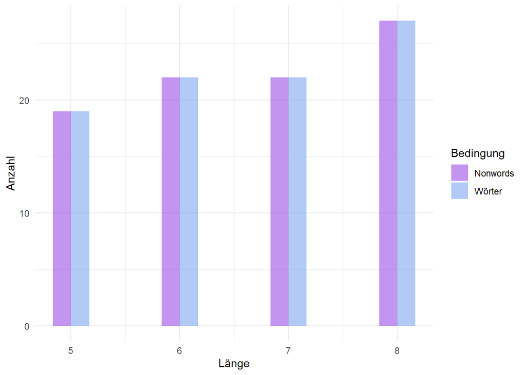

##### Englisch

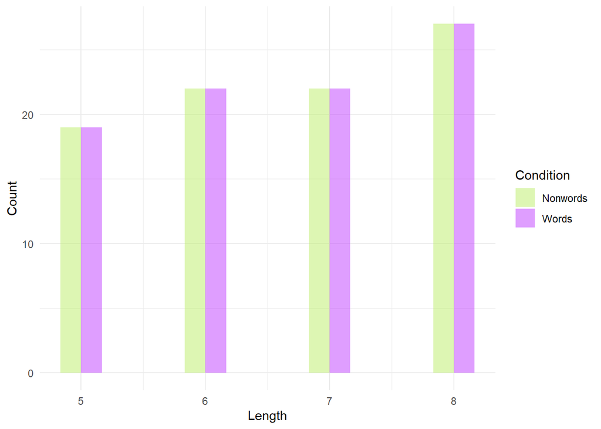

## Frequenz (nur Wörter)

Hier überprüfen wir nun, ob unsere Wörter von ihrer Frequenz her gut verteilt sind. Das ist sehr ähnlich zu dem, was wir bereits in der Stimuliauswahl gemacht haben, und anhand dessen wir unsere Wortliste weiter gekürzt haben. Auch hier sollten uns also keine Überraschungen erwarten.

Hier geben wir den Durchschnitt, die Standardabweichung, das Minimum und das Maximum der Frequenz unserer Wörter aus:

```r
words <- df %>% filter(Condition == "word")

words %>%
  summarise(
    mean_freq = mean(Lg10SUBTLEX_US),
    sd_freq   = sd(Lg10SUBTLEX_US),
    min_freq  = min(Lg10SUBTLEX_US),
    max_freq  = max(Lg10SUBTLEX_US),
    n = n()
  )
```

```
## # A tibble: 1 × 5
##   mean_freq sd_freq min_freq max_freq     n
##       <dbl>   <dbl>    <dbl>    <dbl> <int>
## 1      2.14   0.549     1.15     3.43    90
```

### Plotten

##### Deutsch

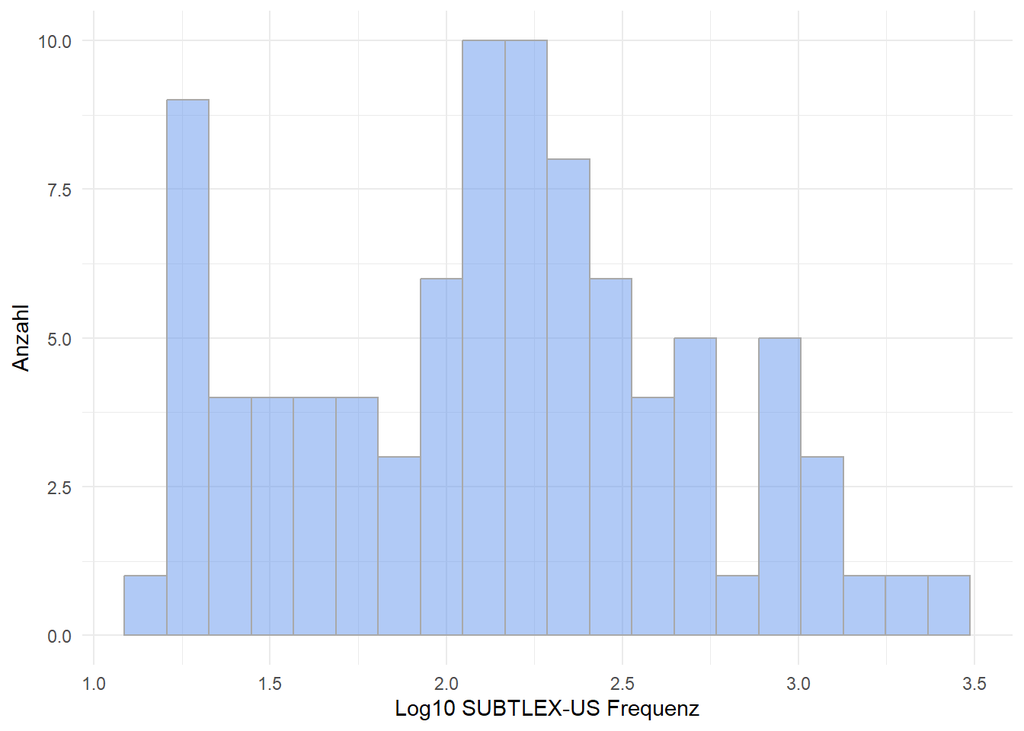

##### Englisch

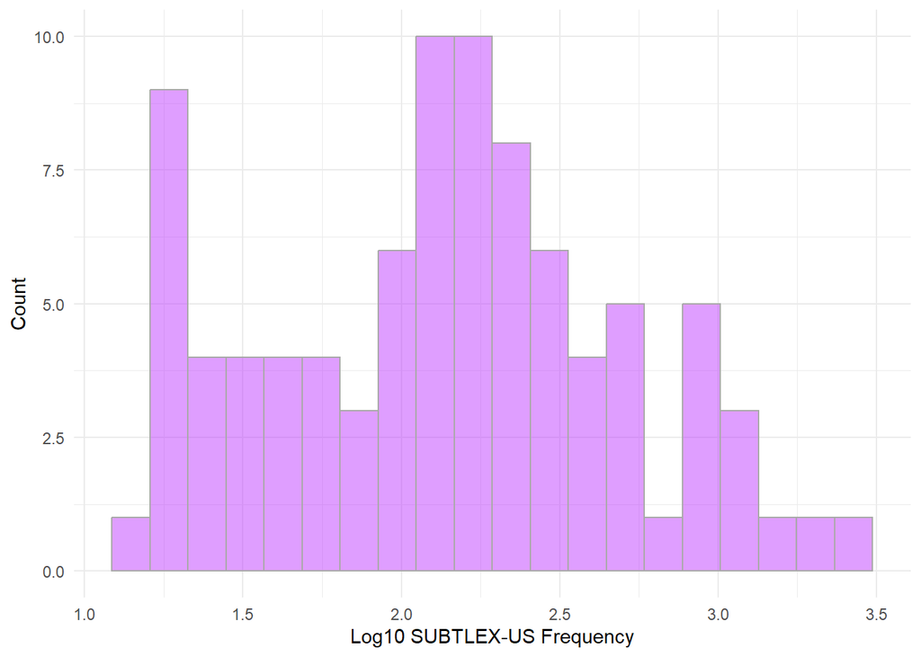